# Quality control of Parsed_proteins_set.txt

Analysis

| R-Analysis Version | 2.11 |
| --- | --- |
| File | D:_portable\4.2.0-Portable_with_QP-proteomics-DA_proteins_set.txt |
| Origin File |  |
| Date | 26-11-13 11:05:26 |

# **Raw data visualization**

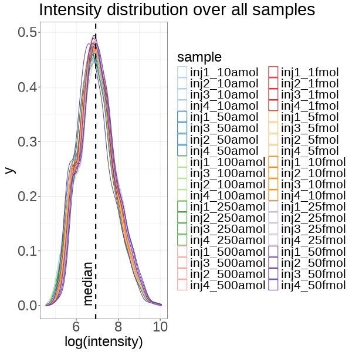

Save figure

Plots density over the log intensity of each sample

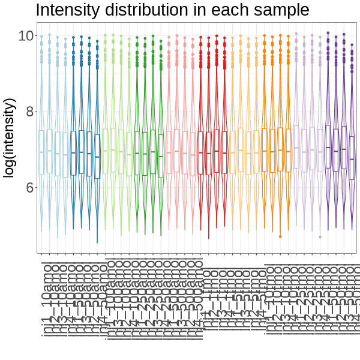

Save figure

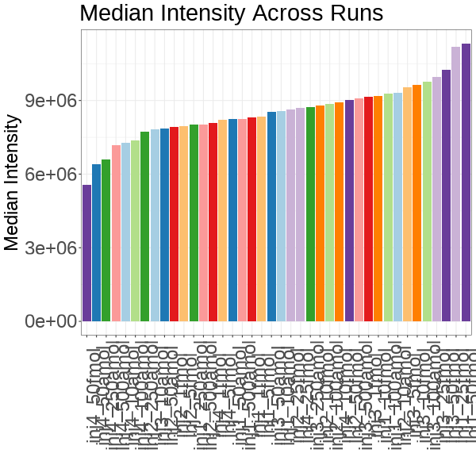

Save figure

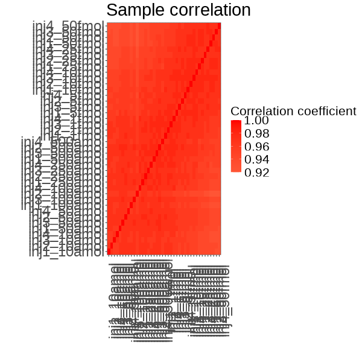

Save figure

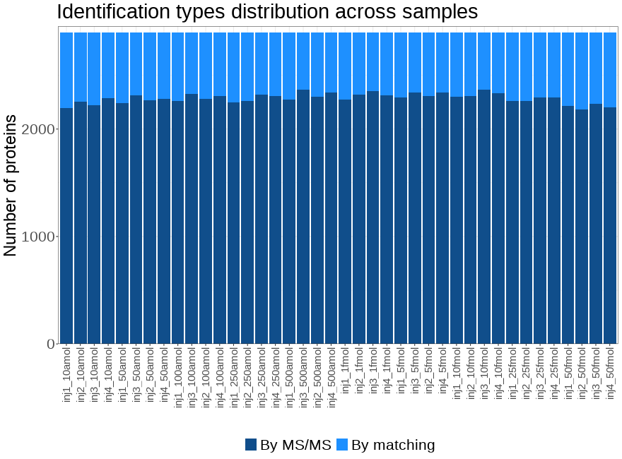

Save figure

# **Normalization**

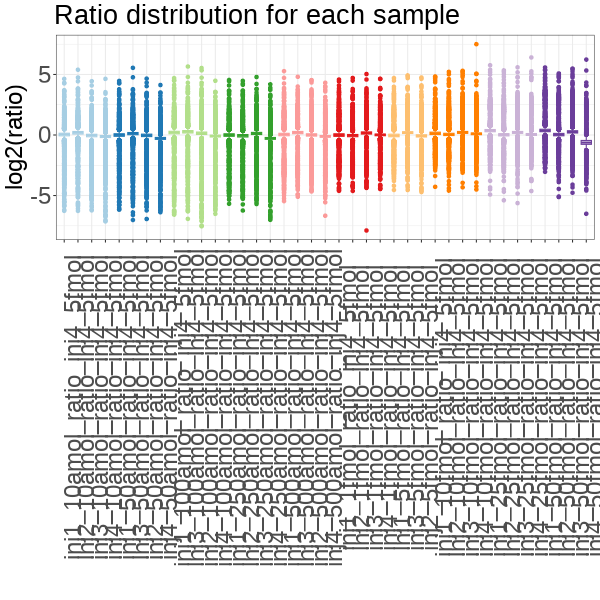

Save figure

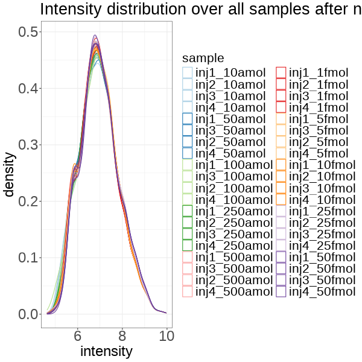

Save figure

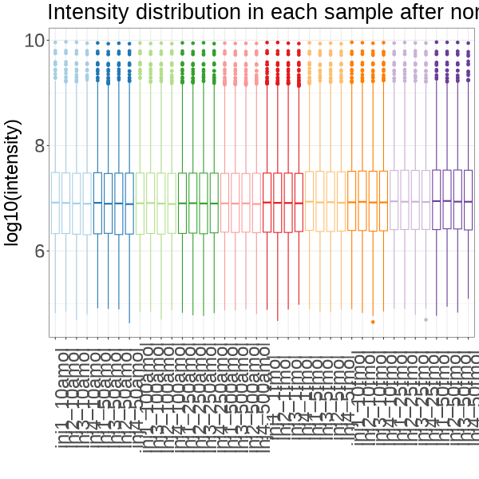

Save figure

Normalization method : each intensity is expressed relatively to a reference intensity, as a ratio of intensities. Intensities of the sample with the lowest number of missing values are used as reference intensities. Intensities are then centered by substracting the median of the ratios for each sample.

# **Missing values imputation**

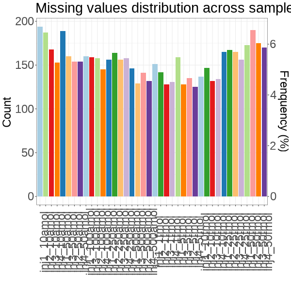

Save figure

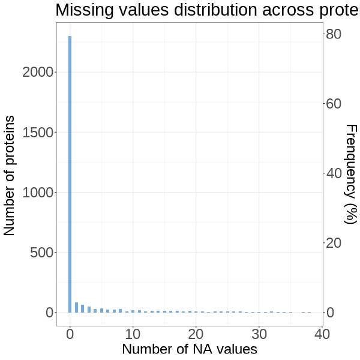

Save figure

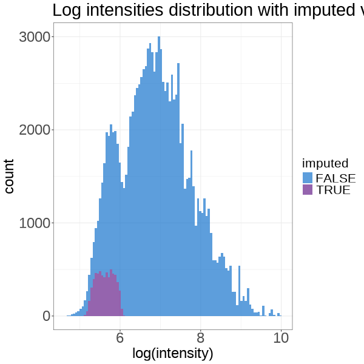

Save figure

Missing values are imputed with the noise model: values are drawn around the noise level of each sample (the 5% percentile of its observed intensities) with a standard deviation of 0.81 log2, estimated on 6701 low-intensity protein measurements within conditions. The imputation uses a fixed seed and is reproducible.

# **Dimension reduction**

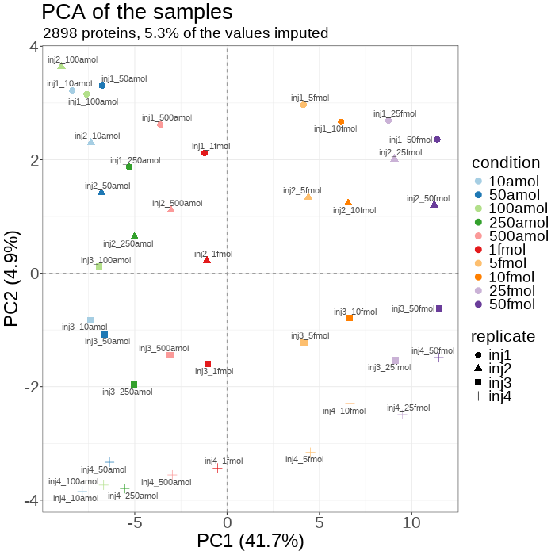

Save figure

Log10 intensities, each protein centered. Proteins vary in weight according to their variance, so the components reflect the largest changes between samples.

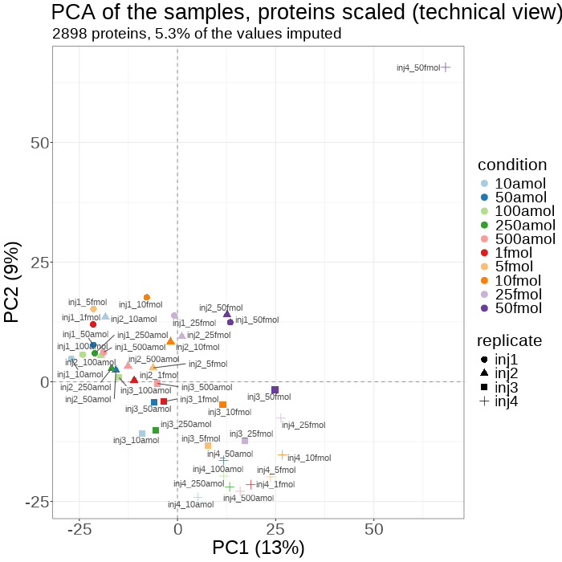

Save figure

Each protein is also scaled to unit variance, so all proteins weigh the same, including the many proteins that do not change. Their technical noise then has as much weight as the biological changes: this view helps to detect technical effects (injection order, batches), not biological ones.

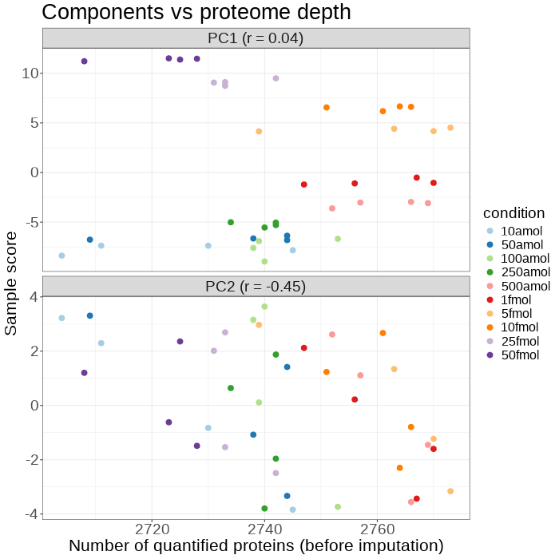

Save figure

Sample scores of the main PCA against the number of proteins quantified in each sample. A strong correlation (|r| close to 1) means that the component mostly reflects differences in proteome depth (and therefore imputed values) rather than biology.

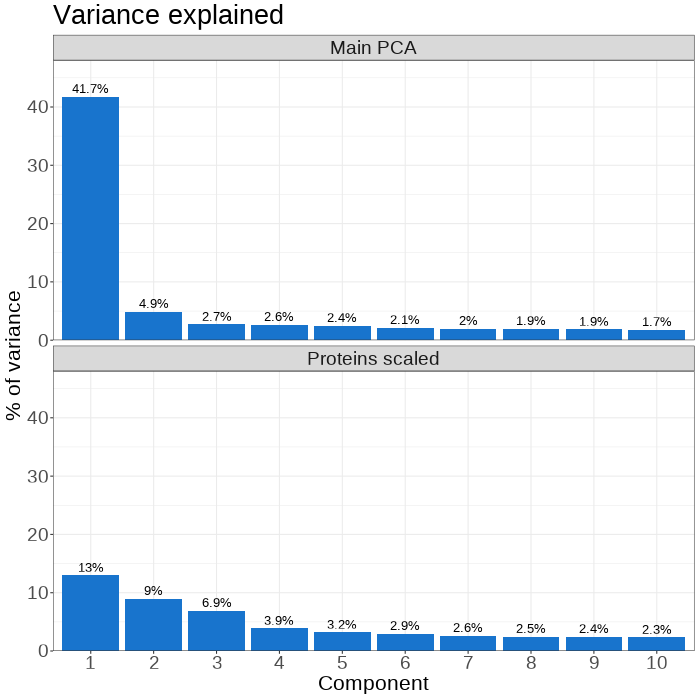

Save figure

Proteins with the largest loadings on PC1 and PC2 of the main PCA (the sign gives the direction along the component)

| Component | Rank | Protein | Loading |
| --- | --- | --- | --- |
| PC1 | 1 | NQO2_HUMAN_UPS | 0.161 |
|  | 2 | UBE2C_HUMAN_UPS | 0.159 |
|  | 3 | CYB5_HUMAN_UPS | 0.158 |
|  | 4 | MYG_HUMAN_UPS | 0.154 |
|  | 5 | NQO1_HUMAN_UPS | 0.154 |
|  | 6 | CAH1_HUMAN_UPS | 0.153 |
|  | 7 | GSTA1_HUMAN_UPS | 0.153 |
|  | 8 | IGF2_HUMAN_UPS | 0.152 |
|  | 9 | CAH2_HUMAN_UPS | 0.148 |
|  | 10 | SYHC_HUMAN_UPS | 0.148 |
| PC2 | 1 | RT07_YEAST | -0.152 |
|  | 2 | SC61G_YEAST | 0.149 |
|  | 3 | HIBCH_YEAST | 0.148 |
|  | 4 | RPF2_YEAST | 0.147 |
|  | 5 | SA155_YEAST | -0.143 |
|  | 6 | AVT1_YEAST | -0.120 |
|  | 7 | SEC15_YEAST | -0.112 |
|  | 8 | ADT1_YEAST | 0.108 |
|  | 9 | FKH1_YEAST | -0.101 |
|  | 10 | PSK1_YEAST | 0.100 |

# **Hierarchical clustering**

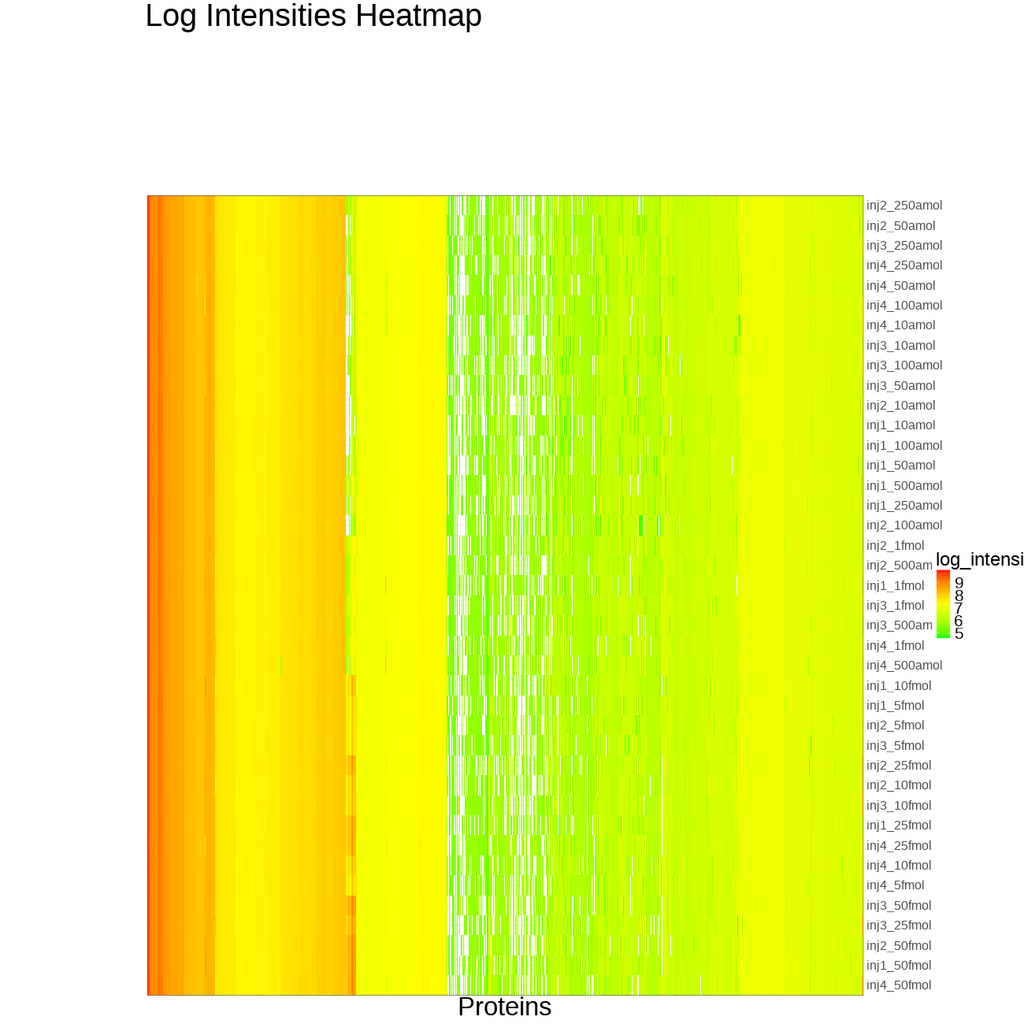

Save figure

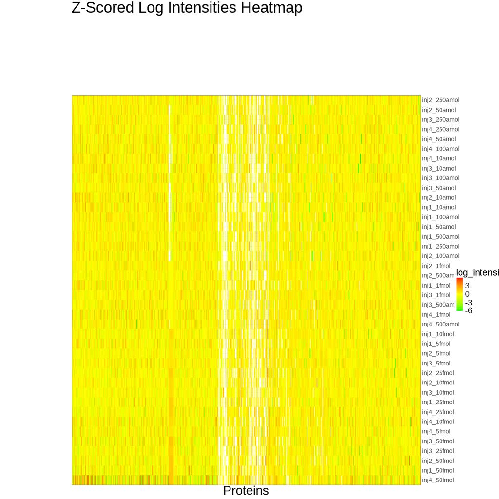

Save figure